# Multivariate model

Como podemos ver las relaciones son redundantes. Una casa que tiene bastante espacio en el primer piso, seguramente tenga un sotano grande; si una casa tiene varios cuartos sobre el nivel del suelo, seguramente tenga un gran espacio sobre el nivel del suelo y por último si el Garage es grande seguramente quepan más carros. Y pues también las casas de alta calidad tendrán un precio más alto. Sabiendo esto se puede ajustar el modelo de regresión lineal.

```
##
## Call:
## lm(formula = SalePrice ~ ., data = data[, vars_quantitative3])
##
## Residuals:
##     Min      1Q  Median      3Q     Max
## -409470  -17579   -3326   14471  339770
##
## Coefficients:
##                 Estimate Std. Error t value Pr(>|t|)
## (Intercept)   -2.982e+05  2.230e+06  -0.134  0.89367
## MSSubClass    -2.600e+02  4.604e+01  -5.648 2.32e-08 ***
## LotFrontage   -1.662e+02  8.914e+01  -1.864  0.06265 .
## LotArea       -2.012e-01  3.702e-01  -0.543  0.58696
## OverallQual    2.150e+04  1.947e+03  11.042  < 2e-16 ***
## OverallCond    3.740e+03  1.824e+03   2.051  0.04064 *
## YearBuilt      3.231e+02  1.183e+02   2.731  0.00647 **
## YearRemodAdd   1.485e+02  1.135e+02   1.308  0.19122
## MasVnrArea     2.202e+01  9.583e+00   2.297  0.02188 *
## BsmtFinSF1     1.490e+01  6.379e+00   2.336  0.01977 *
## BsmtFinSF2     6.134e+00  1.059e+01   0.579  0.56275
## BsmtUnfSF      2.268e+00  5.592e+00   0.405  0.68524
## LowQualFinSF   1.038e+01  3.665e+01   0.283  0.77708
## GrLivArea      6.011e+01  6.667e+00   9.016  < 2e-16 ***
## BsmtFullBath   1.005e+04  4.147e+03   2.425  0.01556 *
## BsmtHalfBath   7.423e+03  7.128e+03   1.041  0.29808
## FullBath       7.237e+03  4.689e+03   1.543  0.12314
## HalfBath      -8.651e+01  3.989e+03  -0.022  0.98270
## BedroomAbvGr  -7.663e+03  2.599e+03  -2.948  0.00330 **
## KitchenAbvGr  -1.447e+04  8.347e+03  -1.733  0.08352 .
## Fireplaces     6.318e+03  2.815e+03   2.245  0.02508 *
## GarageYrBlt   -7.001e+01  1.268e+02  -0.552  0.58089
## GarageArea     4.800e+01  1.185e+01   4.050 5.66e-05 ***
## WoodDeckSF     3.227e+01  1.363e+01   2.367  0.01819 *
## OpenPorchSF   -2.492e+01  2.456e+01  -1.015  0.31052
## EnclosedPorch  7.956e+00  2.761e+01   0.288  0.77332
## X3SsnPorch     3.950e+01  4.292e+01   0.920  0.35777
## ScreenPorch    6.417e+01  2.722e+01   2.358  0.01864 *
## PoolArea      -1.448e+02  5.334e+01  -2.715  0.00678 **
## MiscVal       -2.535e+00  9.608e+00  -0.264  0.79198
## MoSold        -2.047e+02  5.589e+02  -0.366  0.71424
## YrSold        -2.728e+02  1.107e+03  -0.246  0.80538
## ---
## Signif. codes:  0 '***' 0.001 '**' 0.01 '*' 0.05 '.' 0.1 ' ' 1
##
## Residual standard error: 40040 on 740 degrees of freedom
##   (249 observations deleted due to missingness)
## Multiple R-squared:  0.7847, Adjusted R-squared:  0.7757
## F-statistic:    87 on 31 and 740 DF,  p-value: < 2.2e-16
```

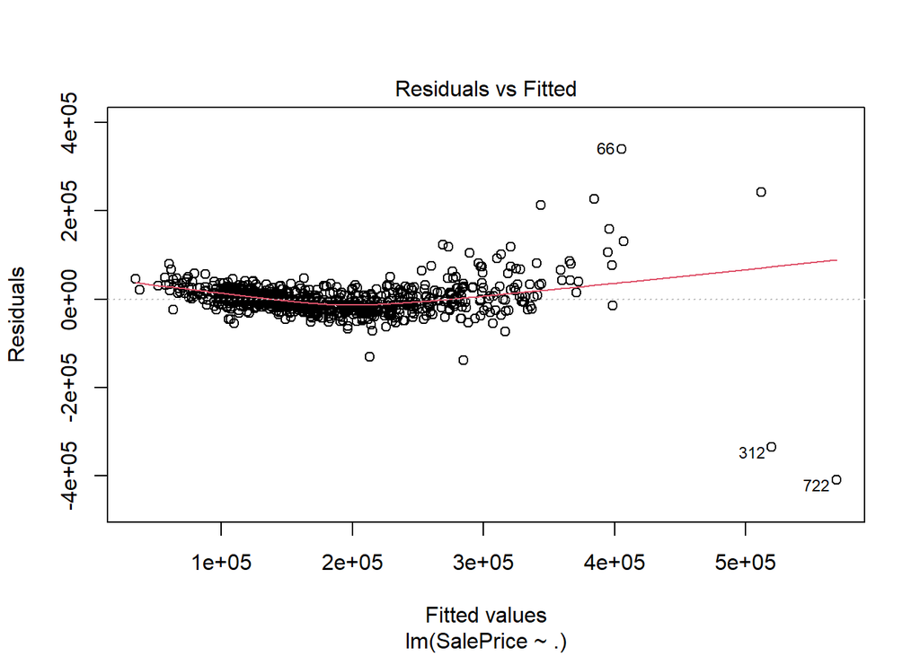

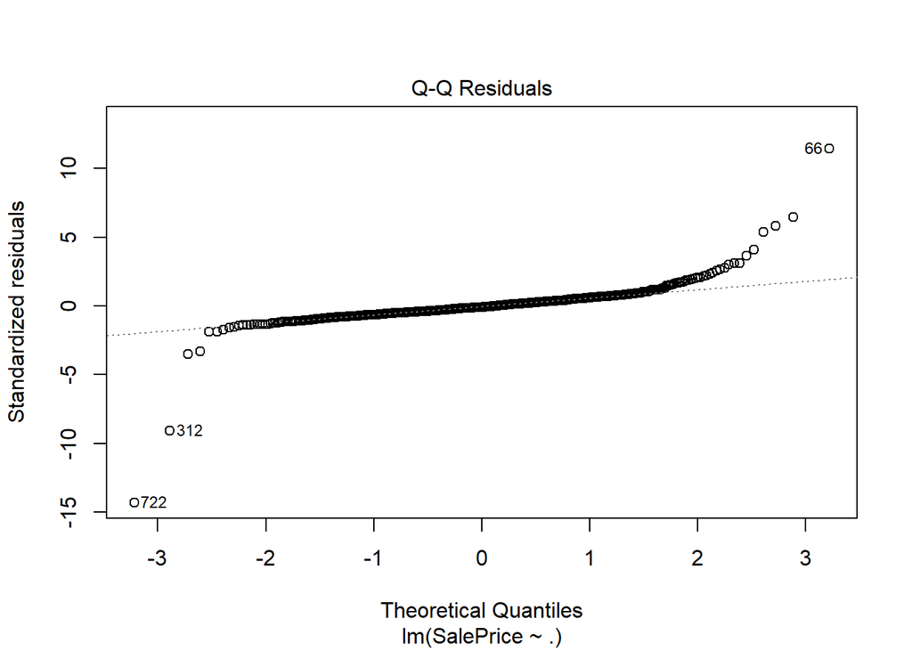

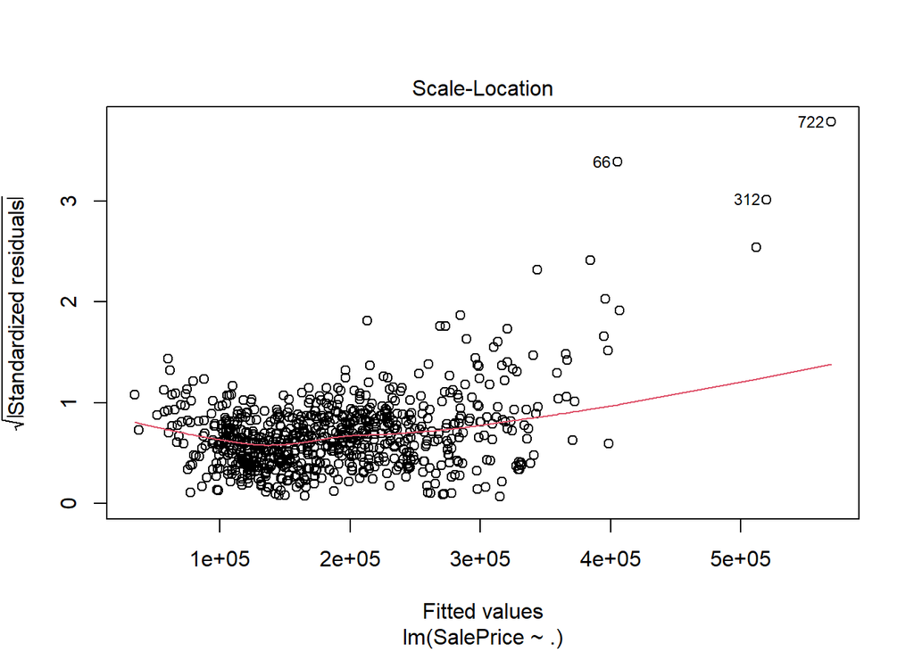

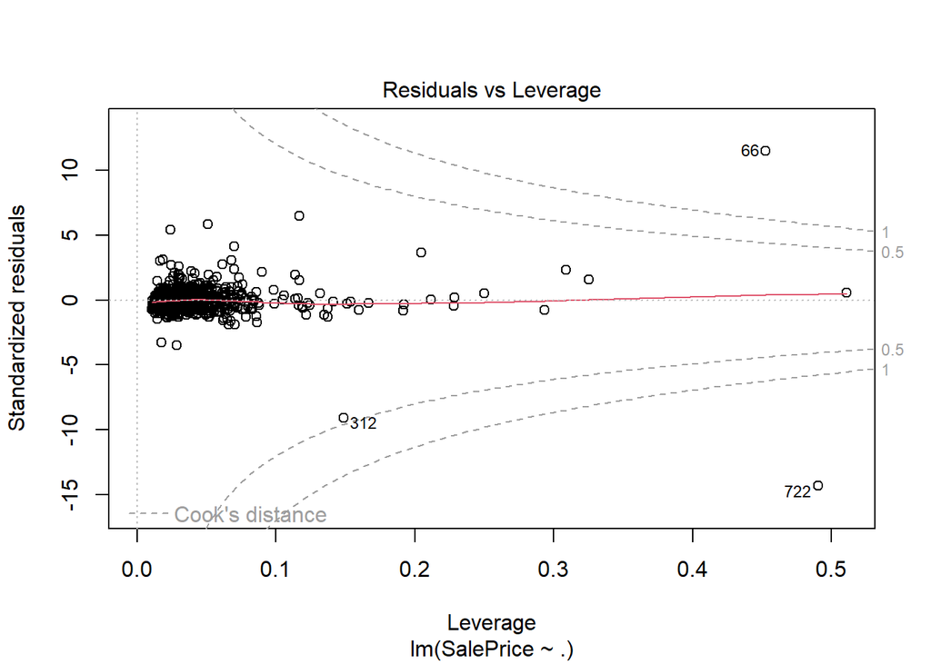

```
## Model :
## SalePrice ~ MSSubClass + LotFrontage + LotArea + OverallQual +
##     OverallCond + YearBuilt + YearRemodAdd + MasVnrArea + BsmtFinSF1 +
##     BsmtFinSF2 + BsmtUnfSF + LowQualFinSF + GrLivArea + BsmtFullBath +
##     BsmtHalfBath + FullBath + HalfBath + BedroomAbvGr + KitchenAbvGr +
##     Fireplaces + GarageYrBlt + GarageArea + WoodDeckSF + OpenPorchSF +
##     EnclosedPorch + X3SsnPorch + ScreenPorch + PoolArea + MiscVal +
##     MoSold + YrSold
```

```
##        1        2        3        4        5        6
## 228872.9 236580.6 286411.2 233100.8       NA 294638.4
```

```
## [1] 90
```

```
## [1] 0
```

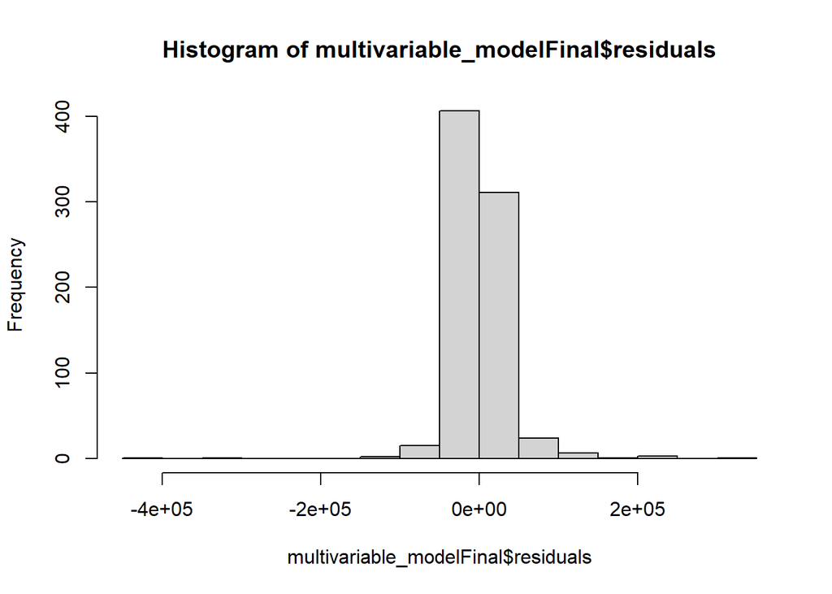

```
##
##  Lilliefors (Kolmogorov-Smirnov) normality test
##
## data:  multivariable_modelFinal$residuals
## D = 0.12271, p-value < 2.2e-16
```

```
## [1] 33501.36
```

```
## [1] 0.1847468
```